S2 Statistika Terapan FMIPA Unpad · Evaluasi Kurikulum 2023

RingkasanRekomendasi

Laporan Evaluasi

# EVALUASI KURIKULUM 2023

Program Studi S2 Statistika Terapan

Fakultas Matematika dan Ilmu Pengetahuan Alam · Universitas Padjadjaran

Basis evaluasi: survei pengguna lulusan · 2–8 Agustus 2024

10

responden pengguna lulusan

83,3%

indeks kompetensi keseluruhan

100%

puas / sangat puas

90%

rekomendasi besar / sangat besar

Executive Summary

## Kurikulum kuat pada fondasi statistik; akselerasi digital menjadi prioritas berikutnya.

- **Kinerja lulusan dinilai kuat.** Rata-rata indeks enam dimensi kompetensi mencapai **83,3%** dari skor maksimum.
- **Kerja sama tim menjadi kekuatan tertinggi (92,5%)**, diikuti kompetensi teknis (87,5%) dan penerapan statistika (85,0%).
- **Big Data/AI/IoT (75,0%)** dan adaptasi Society 5.0 (77,5%) tetap positif, tetapi relatif paling rendah dibanding kompetensi lain.
- **100% pengguna puas/sangat puas** dan 90% menyatakan kemungkinan besar/sangat besar untuk merekomendasikan lulusan.

### Arah keputusan

Pertahankan fondasi statistika yang sudah kuat. Tambahkan lapisan **komputasi modern, AI, komunikasi data, dan project-based learning** secara konsisten lintas mata kuliah.

### Catatan tahun evaluasi

**2023** adalah tahun kurikulum yang dievaluasi. Survei pengguna lulusan dihimpun pada **2–8 Agustus 2024**.

01 · Latar belakang

## Evaluasi diarahkan untuk memastikan kurikulum tetap relevan terhadap kebutuhan kerja dan teknologi.

Evaluasi kurikulum merupakan bagian dari siklus peningkatan mutu berkelanjutan Program Studi S2 Statistika Terapan FMIPA Universitas Padjadjaran. Fokusnya adalah kesesuaian kompetensi lulusan dengan kebutuhan pengguna, perkembangan teknologi, dan prioritas pemutakhiran pembelajaran.

6

### dimensi kompetensi

Kompetensi teknis, penerapan statistika, komunikasi, kerja sama tim, Big Data/AI/IoT, dan adaptasi Society 5.0.

10

### pengguna lulusan

Mencakup pemerintah, penelitian, perbankan, perusahaan swasta, dan usaha digital.

### Metode ringkas

Skala kompetensi dikonversi menjadi skor 4 = Sangat Baik, 3 = Baik, 2 = Cukup Baik, 1 = Kurang Baik. Jawaban terbuka dikelompokkan secara manual dan dapat masuk ke lebih dari satu tema.

02 · Temuan kompetensi

## Kolaborasi dan kompetensi teknis unggul; digital readiness perlu dipercepat.

Semua responden memberikan penilaian minimal **Cukup Baik** pada seluruh dimensi dan tidak ada penilaian Kurang Baik. Polanya menunjukkan fondasi keilmuan sudah kuat, tetapi kompetensi yang berhubungan dengan ekosistem data modern perlu diperdalam.

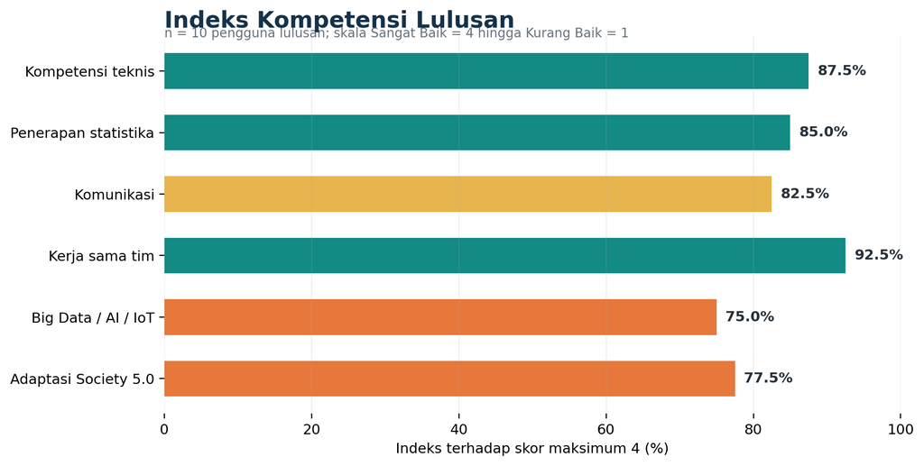

Indeks terhadap skor maksimum 4; n = 10 pengguna lulusan.

| Dimensi | Rata-rata | Indeks | Distribusi ringkas |
| --- | --- | --- | --- |
| Kerja sama tim | 3,70 | 92,5% | 7 Sangat Baik · 3 Baik |
| Kompetensi teknis | 3,50 | 87,5% | 5 Sangat Baik · 5 Baik |
| Penerapan statistika | 3,40 | 85,0% | 4 Sangat Baik · 6 Baik |
| Komunikasi | 3,30 | 82,5% | 4 Sangat Baik · 5 Baik · 1 Cukup Baik |
| Adaptasi Society 5.0 | 3,10 | 77,5% | 3 Sangat Baik · 5 Baik · 2 Cukup Baik |
| Big Data / AI / IoT | 3,00 | 75,0% | 3 Sangat Baik · 4 Baik · 3 Cukup Baik |

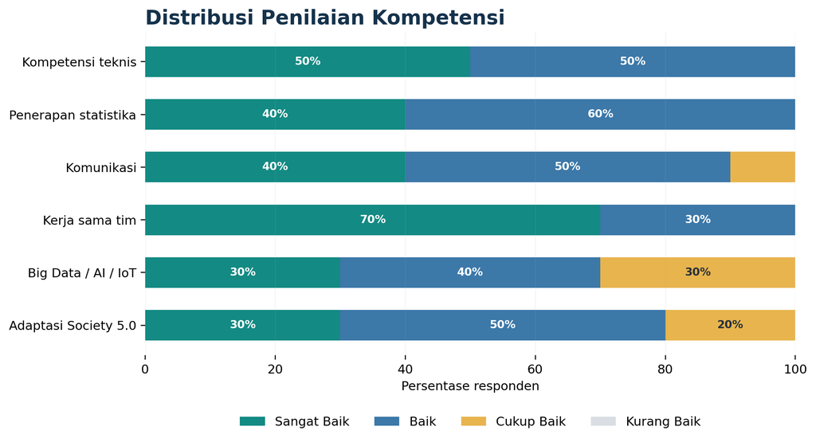

Distribusi kategori penilaian pada enam dimensi kompetensi.

03 · Kepuasan & advocacy

## Pengguna lulusan sangat puas dan memiliki willingness to recommend yang kuat.

Seluruh responden berada pada kategori **Puas atau Sangat Puas**. Dari sisi advocacy, 9 dari 10 responden menyatakan kemungkinan **Besar atau Sangat Besar** untuk merekomendasikan lulusan kepada organisasi lain.

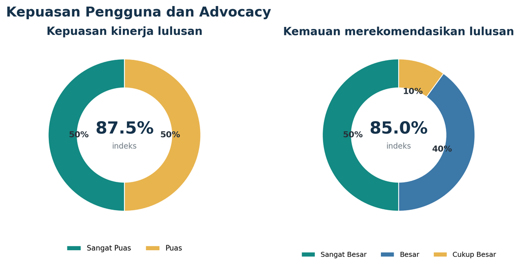

Indeks kepuasan 87,5%; indeks rekomendasi 85,0%.

### Implikasi

Tingkat kepuasan yang tinggi menunjukkan bahwa kurikulum tidak membutuhkan perombakan total. Strategi yang lebih tepat adalah **targeted enhancement** pada kompetensi digital-modern, komunikasi profesional, dan aplikasi real data.

04 · Masukan pengguna

## Permintaan paling konsisten: komputasi modern, komunikasi data, dan kasus nyata.

Jawaban terbuka menunjukkan pengguna menginginkan lulusan yang bukan hanya memahami metode, tetapi mampu mengoperasionalkan metode tersebut dengan perangkat modern, bekerja pada data kompleks, dan menyampaikan insight secara efektif kepada stakeholder.

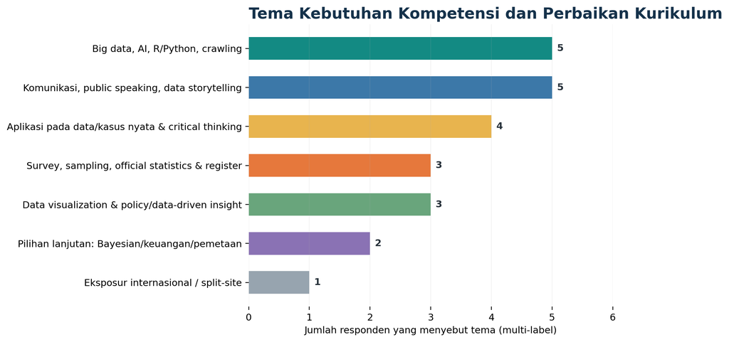

Satu responden dapat menyebut lebih dari satu tema, sehingga kategori bersifat multi-label.

5 responden

### Big data, AI, R/Python & crawling

Penguatan komputasi modern perlu menjadi kompetensi lintas mata kuliah.

5 responden

### Communication of data

Public speaking, data storytelling, visualisasi, dan komunikasi insight perlu dinilai eksplisit.

4 responden

### Real data & critical thinking

Lebih banyak project dengan data nyata, messy data, dan problem organisasi.

05 · Rekomendasi kurikulum

## Enam prioritas perbaikan untuk mempertahankan kekuatan sekaligus meningkatkan future-readiness.

P1

### Integrasikan komputasi modern dan AI ke mata kuliah inti

Perkuat R dan Python, reproducible workflow, big-data processing, web/data crawling, AI-assisted analytics, serta etika dan validasi penggunaan AI melalui tugas dan proyek lintas mata kuliah.

P1

### Wajibkan data communication dan visualization sebagai asesmen

Setiap proyek utama menghasilkan technical report, executive summary, visualisasi, dan presentasi oral; rubrik menilai ketepatan statistik sekaligus keterbacaan insight.

P1

### Perbanyak project berbasis real data dan problem mitra

Gunakan problem BPS, perbankan, pemerintahan, riset, kesehatan, dan bisnis untuk menguji cleaning, merging, validasi, modeling, interpretasi, serta rekomendasi keputusan.

P2

### Perkuat survey sampling dan official statistics

Pertimbangkan sampling sebagai kompetensi inti/modul wajib yang kuat, termasuk register-based statistics, Statistical Business Register, data integration, dan quality assurance.

P2

### Perluas elective basket

Sediakan pilihan seperti Bayesian Statistics, Financial Statistics, Survey & Mapping/Spatial Analytics, Big Data Analytics, dan Policy/Data-Driven Analytics sesuai kebutuhan cohort.

P3

### Dorong exposure internasional

Kembangkan guest lecture internasional, collaborative project, short mobility, atau opsi split-site bila feasible untuk memperluas academic exposure dan networking.

06 · Rencana tindak lanjut

## Rekomendasi diterjemahkan menjadi aksi, output, indikator, dan horizon waktu.

| Prioritas | Aksi | Output | Indikator | Horizon |
| --- | --- | --- | --- | --- |
| P1 | Mapping RPS untuk integrasi R/Python, AI, big data dan real-data project | Matriks CPMK–subCPMK–project | ≥70% MK metode memuat praktik komputasi modern | 1 semester |
| P1 | Standarisasi rubrik komunikasi data | Rubrik presentasi, visualisasi, executive summary | Semua project capstone menilai komunikasi data | 1 semester |
| P1 | Bangun bank kasus mitra | Dataset/problem brief dari pemerintah, industri, riset | ≥5 kasus nyata/tahun tersedia untuk pembelajaran | 1 tahun |
| P2 | Review posisi sampling & official statistics | Keputusan kurikulum/modul wajib | Kompetensi sampling dan data integration terpetakan jelas | 1 tahun |
| P2 | Review dan rotasi mata kuliah pilihan | Elective basket yang responsif | Minimal 3 pilihan relevan kebutuhan digital/sektoral | Tahunan |
| P3 | Program international exposure | Guest lecture/mobility/collaborative project | Minimal 1 kegiatan internasional/cycle | Tahunan |

07 · Caveat & evaluasi berikutnya

## Hasil sangat berguna untuk quality improvement, tetapi perlu dibaca sesuai cakupan sampel.

### Caveat

- Jumlah responden adalah 10 orang.
- Empat responden berasal dari BPS/Badan Pusat Statistik.
- Coding tema jawaban terbuka dilakukan manual dan multi-label.
- Tidak ada pembobotan berdasarkan ukuran organisasi atau jumlah lulusan yang diawasi.

### Pertanyaan evaluasi berikutnya

- Apakah kebutuhan berbeda antar sektor kerja?
- Kompetensi digital mana paling dibutuhkan: data engineering, ML, generative AI, cloud, atau governance?
- Seberapa besar gap kompetensi sebelum dan setelah training internal?
- Bagaimana perubahan penilaian setelah revisi kurikulum diterapkan?

### Kesimpulan

**Pertahankan fondasi statistik yang sudah kuat.** Tingkatkan employability dan future-readiness melalui R/Python, Big Data dan AI, komunikasi data, visualisasi, survey/official statistics, serta project-based learning yang konsisten lintas mata kuliah.

Lampiran

## Profil responden pengguna lulusan

Email responden tidak ditampilkan untuk menjaga laporan tetap profesional dan fokus pada informasi yang relevan dengan evaluasi kurikulum.

| No. | Nama | Instansi | Jabatan |
| --- | --- | --- | --- |
| 1 | Rizka Pradita | BPS | Fungsional |
| 2 | Ade Wahyudi | TEEG Indonesia | Product Manager |
| 3 | Hamim Tsalis Soblia | Badan Pusat Statistik | Statistisi Muda |
| 4 | Ani Pertiwi | BPS | Statistisi Ahli Muda |
| 5 | Cepy Ramdhani | BPS | Widyaiswara |
| 6 | Tafia Hasna Putri | LK3P UI | Asisten Peneliti |
| 7 | Elyn Prina | DJP | Pelaksana |
| 8 | Hilman Sembada | bank bjb | Pemimpin Grup Manajemen Risiko Kredit |
| 9 | Imanudin | Sibosdigital | Owner |
| 10 | Yunita Dwi Ayu Ningtias | PT Akur Pratama | Supervisor |

**S2 Statistika Terapan FMIPA Universitas Padjadjaran**  
Laporan Evaluasi Kurikulum 2023 · Survei pengguna lulusan Agustus 2024

Dokumen evaluasi mutu internal